# Alt Approaches Step 2: Load Raw Counts

Adam Festa

4/19/2018

## Script objective

This script preps the raw bioloigcal replicate count/experimental data for normalization by:

```
* Removing low expressed counts

* Identifying potential outlier replicates

* Combining counts with complete expermiental meta-data
```

See: analyses/step1.data_prep/README.md for how input data to this script was generated.

## Load data from previous run

- Load the tximport object which contains biological replciates

  ```r
    # bio counts
    load("/media/disk6/ARF/RNASEQ/counts/86kSalmon/bio_rep_txi_count_data_object.RData")
    names(txi)
  ```

  ```
  ## [1] "abundance"           "counts"              "variance"
  ## [4] "length"              "countsFromAbundance"
  ```

  - The txi object is a list of 5 elements containing the counts, bootstrap variance estimates, and effect txpt lengths for each respective sample.
- Load complete experimental meta data

  ```r
    # expt data
    load("/media/disk6/ARF/RNASEQ/Breeding-Value-Prediction/disk6directory/resources/expt.dat.720.RData")
    dim(expt.dat.720)
  ```

  ```
  ## [1] 720  36
  ```

  - The experimental data set contain 720 rows and 36 columns. Each row correspond to a technical replicate and each column corresponds to a piece of meta-deta describing the techincal replicate.
  - Note that the experiment meta-data needs to be consolidated to bioloigcal replicates in order to match the txi object. This will be done next by identifying the column names and removing certain ones which uniquely describe the techincal replicates.

## Combine raw counts and experiment info

- Print the column names of the experimental data frame.

  ```r
  colnames(expt.dat.720)
  ```

  ```
  ##  [1] "animal_id"          "fam_id"             "p1"
  ##  [4] "p2"                 "batch"              "lane"
  ##  [7] "index_seq"          "fl_mean"            "index_let"
  ## [10] "sample_id"          "salmon_input_path"  "p_info"
  ## [13] "Height"             "Height Accuracy"    "Height LB"
  ## [16] "Height UB"          "Volume"             "Volume Accuracy"
  ## [19] "Volume LB"          "Volume UB"          "Rust"
  ## [22] "Rust Accuracy"      "Rust LB"            "Rust UB"
  ## [25] "Rust Grade"         "Strt"               "Strt Accuracy"
  ## [28] "Strt LB"            "Strt UB"            "Strt Grade"
  ## [31] "Fork"               "Fork Accuracy"      "Fork LB"
  ## [34] "Fork UB"            "Fork Grade"         "salmon_output_path"
  ```

  - Lot’s of stuff in here. The ones which are unique to technical replicates within a given biological replicate are:
    - lane (col 6)
    - fl_mean (col 8)
    - salmple_id (col 10)
    - salmon_input_path (col 11)
    - salmon_output_path (col 36)
- Remove the above columns and reduce the experiment info matrix to the level of bioloigcal replicates

  ```r
  rm.cols <- c(6,8,10,11,36)

  expt.dat.240 <- droplevels.data.frame(unique(expt.dat.720[,-c(rm.cols)]))
  dim(expt.dat.240)
  ```

  ```
  ## [1] 240  31
  ```

- Now that we have both the count data and experimental meta data consolidated to bioloigcal replicates, let’s check that they are in same order.

  ```r
  # print the column names of the counts (biological replicate names)
  head(colnames(txi$counts))
  ```

  ```
  ## [1] "1030." "1028." "1075." "1087." "1013." "1079."
  ```

  ```r
  #look at name of animal.id (bioloigcal replicate) in experimental info
  head(expt.dat.240$animal_id)
  ```

  ```
  ## [1] 1030 1028 1075 1087 1013 1079
  ## 240 Levels: 1 10 100 1001 1002 1003 1004 1005 1006 1007 1008 1009 ... 99
  ```

  - Note that column names in the counts are characters while the experimental data animal id is a numeric factor.
  - Also, note that each biological sample name in the counts has a “.” at the end which will force R to never specify this as anything but a character variable.
- Add period to end of animal id, check order, and assign as row names of expt data frame

  ```r
  tmp.names <- paste0(as.character(expt.dat.240$animal_id),".")
  identical(tmp.names,colnames(txi$counts))
  ```

  ```
  ## [1] TRUE
  ```

  ```r
  rownames(expt.dat.240) <- tmp.names
  ```

## Pre-filter data and check for outliers

- Filter out low expressed counts (total sum < 10) from txi object

  ```r
  # Filter out which transcripts have less than 10 total counts
  rm.zero <- which(apply(txi$counts,1,sum) < 10)
  txi$counts <- txi$counts[-c(rm.zero),]

  # Remove low counts from remaining objects in the list
  txi$abundance <- txi$abundance[-c(rm.zero),]
  txi$length <- txi$length[-c(rm.zero),]
  txi$variance <- txi$variance[-c(rm.zero),]
  ```

- Generate pc plot and check outliers

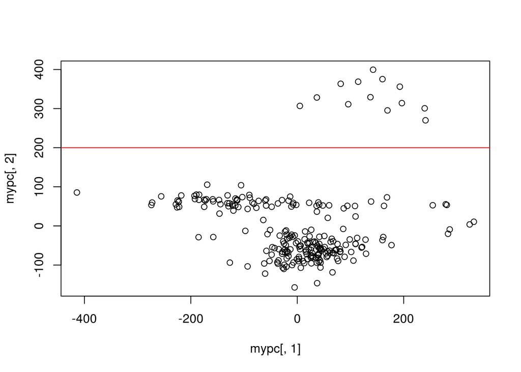

  ```r
  # Use the counts to create a pc plot and plot the first two
  mypc <- prcomp(t(txi$counts),center = T,scale. = T)
  mypc <- mypc$x[,1:2]
  plot(mypc[,1],mypc[,2]); abline(h=200,col="red")
  ```

  ```r
  # Which reps are outliers?
  sort(names(which(mypc[,2] > 200)))
  ```

  ```
  ##  [1] "1069." "1070." "1071." "1072." "1073." "1074." "1075." "1076."
  ##  [9] "1079." "1080." "1081." "1083." "1084."
  ```

- Remove outlier biological replicates

  ```r
  # Identify the rows which correspond to the outliers
  rm.bio.reps <- which(mypc[,2] > 200)
  # Subset the txi and pheno objects to remove families with less than 3 bio reps per batch
  txi$counts <- txi$counts[,-c(rm.bio.reps)]

  rm.zero <- which(apply(txi$counts,1,sum) < 10)
  txi$counts <- txi$counts[-c(rm.zero),]
  txi$abundance <- txi$abundance[-c(rm.zero),-c(rm.bio.reps)]
  txi$variance <- txi$variance[-c(rm.zero),-c(rm.bio.reps)]
  txi$length <- txi$length[-c(rm.zero),-c(rm.bio.reps)]

  sub.phenos <- droplevels.data.frame(expt.dat.240[-c(rm.bio.reps),])

  unique(sub.phenos$fam_id)
  ```

  ```
  ##  [1] N111095         WG7720          WG7442          WG7206
  ##  [5] N07058          N08103          N08059          N101027
  ##  [9] WG1809          WG4501          LSG111          N111062
  ## [13] WG7478          WG7083          N051501         N12008
  ## [17] WG7192          WG4801          N22204          N22269
  ## [21] N08001          WG4302          N08061          N07056
  ## [25] N07105          N051049         N22212          N07100
  ## [29] N071084         N111111         N091083xN25063  N25073
  ## [33] N11061          N11010          N111027         N10005
  ## [37] N22010          N22005          N10010          N22029
  ## [41] N22044          N111111xC21B    N22063          N101029
  ## [45] N25064          N22033          N25075          N111069
  ## [49] N10005xUC       N111066         N26004          N22029xB48
  ## [53] N02005          N22057          N071037         N26001
  ## [57] N25070          N22055          N081072         N091083
  ## [61] N11016          N22010xN22037   N10010xB21      N071011
  ## [65] N071096         N25073xBA2L20   N091019         N081072xN101047
  ## [69] N22024          N07002
  ## 70 Levels: LSG111 N02005 N051049 N051501 N07002 N07056 N07058 ... WG7720
  ```

- Generate pc plot and check outliers

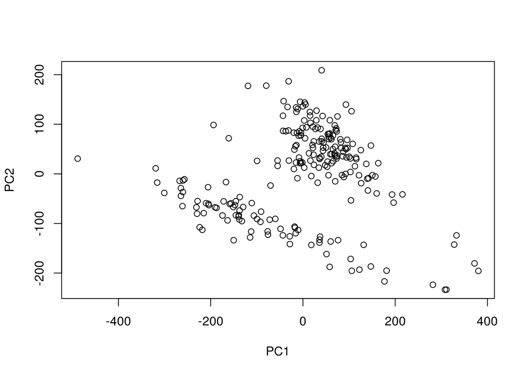

  ```r
  # Use the counts to create a pc plot and plot the first two
  mypc <- prcomp(t(txi$counts),center = T,scale. = T)
  mypc <- mypc$x[,1:2]
  plot(mypc)
  ```

  - The EW and LGEP are parallel to one another on the plot above. How would the samples look if we created a PC plot using only the LGEP or EW?

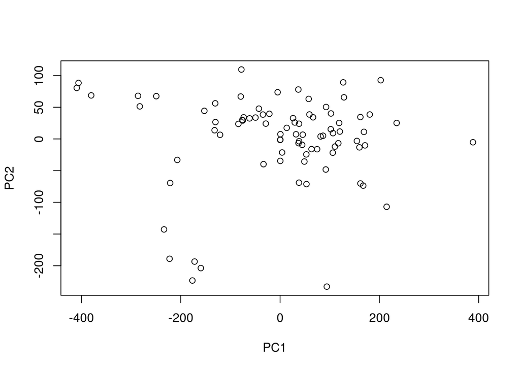

  ```r
  ew.reps <- which(sub.phenos$batch == "EW")
  ew.cts <- txi$counts[,ew.reps]
  rm.zero <- which(apply(ew.cts,1,sum) <= 10)
  ew.cts <- ew.cts[-c(rm.zero),]

  mypc <- prcomp(t(ew.cts),center = T,scale. = T)
  mypc <- mypc$x[,1:2]
  plot(mypc)
  ```

  ```r
  sort(names(which(mypc[,2] < -100)))
  ```

  ```
  ## [1] "1035." "1036." "1037." "1038." "1045." "1047." "1062."
  ```

  ```r
  which(mypc[,1] > 0 & mypc[,2] < -200)
  ```

  ```
  ## 1035.
  ##    80
  ```

  - Now look at LGEP:

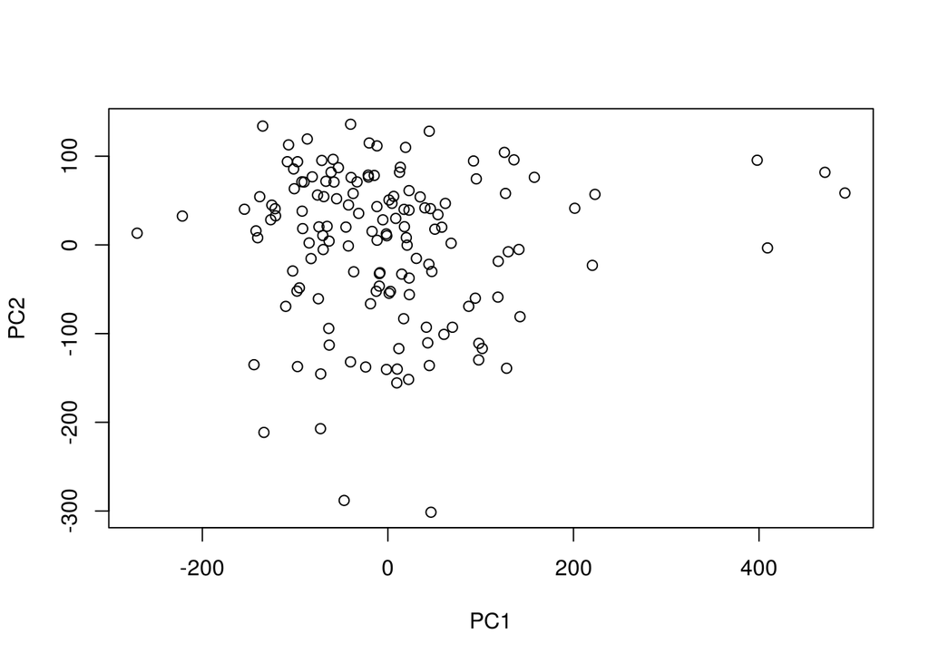

  ```r
  lgep.reps <- which(sub.phenos$batch == "LGEP")
  lgep.cts <- txi$counts[,lgep.reps]
  rm.zero <- which(apply(lgep.cts,1,sum) <= 10)
  lgep.cts <- lgep.cts[-c(rm.zero),]

  mypc <- prcomp(t(lgep.cts),center = T,scale. = T)
  mypc <- mypc$x[,1:2]
  plot(mypc)
  ```

  ```r
  which(mypc[,1] > 300)
  ```

  ```
  ## 133.  67.  13.  10.
  ##   95  114  115  144
  ```

- Probably should keep an eye on the above samples, but prior to normalization there is nothing to suggest that these samples are “bad”

## Save output

- Now let’s save the objects which will be used for normalization

  ```r
  load.counts <- vector("list")
  load.counts$txi_object <- txi
  load.counts$phenos <- sub.phenos

  save(load.counts,file="/media/disk6/ARF/RNASEQ/counts/86kSalmon/Step2_Load_Counts.RData",compress=T)
  ```